# Biostat 203B Homework 2

Due Feb 6 @ 11:59PM

Yuhang Qian

```r
knitr::opts_chunk$set(echo = TRUE, cache = TRUE, cache.lazy = FALSE)
library(tidyverse)
library(data.table)
library(lubridate)
```

```r
os <- sessionInfo()$running
if (str_detect(os, "Linux")) {
  mimic_path <- "/mnt/mimiciv/1.0"
} else if (str_detect(os, "macOS")) {
  mimic_path <- "/Users/huazhou/Documents/Box Sync/MIMIC/mimic-iv-1.0"
}
```

In this exercise, we use tidyverse (ggpot2, dplyr, etc) to explore the [MIMIC-IV](https://mimic.mit.edu/docs/iv/) data introduced in [homework 1](https://ucla-biostat-203b.github.io/2022winter/hw/hw1/hw1.html) and to build a cohort of ICU stays.

```r
# tree -s -L 2 /Users/huazhou/Documents/Box\ Sync/MIMIC/mimic-iv-1.0
system(str_c("tree -s -L 2 ", shQuote(mimic_path)), intern = TRUE)
```

```
##  [1] "/mnt/mimiciv/1.0"
##  [2] "├── [       4096]  core"
##  [3] "│   ├── [   17208966]  admissions.csv.gz"
##  [4] "│   ├── [        606]  index.html"
##  [5] "│   ├── [    2955582]  patients.csv.gz"
##  [6] "│   └── [   53014503]  transfers.csv.gz"
##  [7] "├── [       4096]  hosp"
##  [8] "│   ├── [     430049]  d_hcpcs.csv.gz"
##  [9] "│   ├── [   29531152]  diagnoses_icd.csv.gz"
## [10] "│   ├── [     863239]  d_icd_diagnoses.csv.gz"
## [11] "│   ├── [     579998]  d_icd_procedures.csv.gz"
## [12] "│   ├── [      14898]  d_labitems.csv.gz"
## [13] "│   ├── [   11684062]  drgcodes.csv.gz"
## [14] "│   ├── [  515763427]  emar.csv.gz"
## [15] "│   ├── [  476252563]  emar_detail.csv.gz"
```

[output cut: 24 more lines]

## Q1. `read.csv` (base R) vs `read_csv` (tidyverse) vs `fread` (data.table)

There are quite a few utilities in R for reading plain text data files. Let us test the speed of reading a moderate sized compressed csv file, `admissions.csv.gz`, by three programs: `read.csv` in base R, `read_csv` in tidyverse, and `fread` in the popular data.table package.

Which function is fastest?

```r
system.time(read.csv("/mnt/mimiciv/1.0/core/admissions.csv.gz"))
```

```
##    user  system elapsed
##  40.736   0.250  41.009
```

```r
system.time(read_csv("/mnt/mimiciv/1.0/core/admissions.csv.gz"))
```

```
##    user  system elapsed
##   3.417   0.263   3.234
```

```r
system.time(fread("/mnt/mimiciv/1.0/core/admissions.csv.gz"))
```

```
##    user  system elapsed
##   1.695   0.103   2.434
```

*Function `fread` is fastest. `fread` is faster than `read_csv`, and `read_csv` is faster than `read.csv`.*

Is there difference in the (default) parsed data types? (Hint: R function `system.time` measures run times.)

```r
str(read.csv("/mnt/mimiciv/1.0/core/admissions.csv.gz"))
```

```
## 'data.frame':    523740 obs. of  15 variables:
##  $ subject_id          : int  14679932 15585972 11989120 17817079 15078341 19124609 17301855 17991012 16865435 13693648 ...
##  $ hadm_id             : int  21038362 24941086 21965160 24709883 23272159 20517215 29732723 24298836 23216961 21640725 ...
##  $ admittime           : Factor w/ 514435 levels "2105-10-04 17:26:00",..: 162283 62357 210124 330971 56261 351331 166789 430755 456181 3345 ...
##  $ dischtime           : Factor w/ 507789 levels "2105-10-12 11:11:00",..: 160158 61694 207314 326516 55632 346651 164592 424886 449948 3316 ...
##  $ deathtime           : Factor w/ 9337 levels "","2110-01-25 09:40:00",..: 1 1 1 1 1 1 1 1 1 1 ...
##  $ admission_type      : Factor w/ 9 levels "AMBULATORY OBSERVATION",..: 4 4 4 4 4 4 4 4 4 4 ...
##  $ admission_location  : Factor w/ 12 levels "","AMBULATORY SURGERY TRANSFER",..: 1 1 1 1 1 1 1 1 1 1 ...
##  $ discharge_location  : Factor w/ 14 levels "","ACUTE HOSPITAL",..: 8 8 8 8 8 8 8 8 8 8 ...
##  $ insurance           : Factor w/ 3 levels "Medicaid","Medicare",..: 3 3 3 3 3 3 3 3 3 3 ...
##  $ language            : Factor w/ 2 levels "?","ENGLISH": 2 2 2 2 2 2 2 2 2 2 ...
##  $ marital_status      : Factor w/ 5 levels "","DIVORCED",..: 4 1 1 1 1 1 1 1 1 1 ...
##  $ ethnicity           : Factor w/ 8 levels "AMERICAN INDIAN/ALASKA NATIVE",..: 7 8 7 5 3 7 8 8 8 8 ...
##  $ edregtime           : Factor w/ 310256 levels "","2109-08-31 02:46:00",..: 1 1 1 1 1 1 1 1 1 1 ...
##  $ edouttime           : Factor w/ 310322 levels "","2109-08-31 07:51:00",..: 1 1 1 1 1 1 1 1 1 1 ...
##  $ hospital_expire_flag: int  0 0 0 0 0 0 0 0 0 0 ...
```

```r
str(read_csv("/mnt/mimiciv/1.0/core/admissions.csv.gz",
             show_col_types = FALSE))
```

```
## spec_tbl_df [523,740 × 15] (S3: spec_tbl_df/tbl_df/tbl/data.frame)
##  $ subject_id          : num [1:523740] 14679932 15585972 11989120 17817079 15078341 ...
##  $ hadm_id             : num [1:523740] 21038362 24941086 21965160 24709883 23272159 ...
##  $ admittime           : POSIXct[1:523740], format: "2139-09-26 14:16:00" "2123-10-07 23:56:00" ...
##  $ dischtime           : POSIXct[1:523740], format: "2139-09-28 11:30:00" "2123-10-12 11:22:00" ...
##  $ deathtime           : POSIXct[1:523740], format: NA NA ...
##  $ admission_type      : chr [1:523740] "ELECTIVE" "ELECTIVE" "ELECTIVE" "ELECTIVE" ...
##  $ admission_location  : chr [1:523740] NA NA NA NA ...
##  $ discharge_location  : chr [1:523740] "HOME" "HOME" "HOME" "HOME" ...
##  $ insurance           : chr [1:523740] "Other" "Other" "Other" "Other" ...
##  $ language            : chr [1:523740] "ENGLISH" "ENGLISH" "ENGLISH" "ENGLISH" ...
##  $ marital_status      : chr [1:523740] "SINGLE" NA NA NA ...
##  $ ethnicity           : chr [1:523740] "UNKNOWN" "WHITE" "UNKNOWN" "OTHER" ...
##  $ edregtime           : POSIXct[1:523740], format: NA NA ...
##  $ edouttime           : POSIXct[1:523740], format: NA NA ...
##  $ hospital_expire_flag: num [1:523740] 0 0 0 0 0 0 0 0 0 0 ...
##  - attr(*, "spec")=
##   .. cols(
##   ..   subject_id = col_double(),
##   ..   hadm_id = col_double(),
##   ..   admittime = col_datetime(format = ""),
##   ..   dischtime = col_datetime(format = ""),
##   ..   deathtime = col_datetime(format = ""),
##   ..   admission_type = col_character(),
##   ..   admission_location = col_character(),
##   ..   discharge_location = col_character(),
##   ..   insurance = col_character(),
##   ..   language = col_character(),
##   ..   marital_status = col_character(),
##   ..   ethnicity = col_character(),
##   ..   edregtime = col_datetime(format = ""),
##   ..   edouttime = col_datetime(format = ""),
##   ..   hospital_expire_flag = col_double()
##   .. )
##  - attr(*, "problems")=<externalptr>
```

```r
str(fread("/mnt/mimiciv/1.0/core/admissions.csv.gz"))
```

```
## Classes 'data.table' and 'data.frame':   523740 obs. of  15 variables:
##  $ subject_id          : int  14679932 15585972 11989120 17817079 15078341 19124609 17301855 17991012 16865435 13693648 ...
##  $ hadm_id             : int  21038362 24941086 21965160 24709883 23272159 20517215 29732723 24298836 23216961 21640725 ...
##  $ admittime           : POSIXct, format: "2139-09-26 14:16:00" "2123-10-07 23:56:00" ...
##  $ dischtime           : POSIXct, format: "2139-09-28 11:30:00" "2123-10-12 11:22:00" ...
##  $ deathtime           : POSIXct, format: NA NA ...
##  $ admission_type      : chr  "ELECTIVE" "ELECTIVE" "ELECTIVE" "ELECTIVE" ...
##  $ admission_location  : chr  "" "" "" "" ...
##  $ discharge_location  : chr  "HOME" "HOME" "HOME" "HOME" ...
##  $ insurance           : chr  "Other" "Other" "Other" "Other" ...
##  $ language            : chr  "ENGLISH" "ENGLISH" "ENGLISH" "ENGLISH" ...
##  $ marital_status      : chr  "SINGLE" "" "" "" ...
##  $ ethnicity           : chr  "UNKNOWN" "WHITE" "UNKNOWN" "OTHER" ...
##  $ edregtime           : POSIXct, format: NA NA ...
##  $ edouttime           : POSIXct, format: NA NA ...
##  $ hospital_expire_flag: int  0 0 0 0 0 0 0 0 0 0 ...
##  - attr(*, ".internal.selfref")=<externalptr>
```

```r
#head(read.csv("/mnt/mimiciv/1.0/core/admissions.csv.gz"))
#head(read_csv("/mnt/mimiciv/1.0/core/admissions.csv.gz",
#                show_col_types = FALSE))
#head(fread("/mnt/mimiciv/1.0/core/admissions.csv.gz"))
```

*Using the `str` function, we can check the parsed data types of these three programs. `read.csv` generates a data frame; `read_csv` generates a tibble; `fread` generates a data table.*

For later questions, we stick to the tidyverse.

## Q2. ICU stays

`icustays.csv.gz` (https://mimic.mit.edu/docs/iv/modules/icu/icustays/) contains data about Intensive Care Units (ICU) stays. The first 10 lines are

```r
system(
  str_c(
    "zcat < ",
    shQuote(str_c(mimic_path, "/icu/icustays.csv.gz")),
    " | head"
    ),
  intern = TRUE
)
```

```
##  [1] "subject_id,hadm_id,stay_id,first_careunit,last_careunit,intime,outtime,los"
##  [2] "17867402,24528534,31793211,Trauma SICU (TSICU),Trauma SICU (TSICU),2154-03-03 04:11:00,2154-03-04 18:16:56,1.5874537037037035"
##  [3] "14435996,28960964,31983544,Trauma SICU (TSICU),Trauma SICU (TSICU),2150-06-19 17:57:00,2150-06-22 18:33:54,3.025625"
##  [4] "17609946,27385897,33183475,Trauma SICU (TSICU),Trauma SICU (TSICU),2138-02-05 18:54:00,2138-02-15 12:42:05,9.741724537037038"
##  [5] "18966770,23483021,34131444,Trauma SICU (TSICU),Trauma SICU (TSICU),2123-10-25 10:35:00,2123-10-25 18:59:47,0.35054398148148147"
##  [6] "12776735,20817525,34547665,Neuro Stepdown,Neuro Stepdown,2200-07-12 00:33:00,2200-07-13 16:44:40,1.6747685185185184"
##  [7] "10215159,24283593,34569476,Trauma SICU (TSICU),Trauma SICU (TSICU),2124-09-20 15:05:29,2124-09-21 22:06:58,1.2926967592592593"
##  [8] "14489052,26516390,35056286,Trauma SICU (TSICU),Trauma SICU (TSICU),2118-10-26 10:33:56,2118-10-26 20:28:10,0.4126620370370371"
##  [9] "15914763,28906020,36909804,Trauma SICU (TSICU),Trauma SICU (TSICU),2176-12-14 12:00:00,2176-12-17 11:47:01,2.9909837962962964"
## [10] "16256226,20013290,39289362,Neuro Stepdown,Neuro Stepdown,2150-12-20 16:09:08,2150-12-21 14:58:40,0.9510648148148149"
```

1. Import `icustatys.csv.gz` as a tibble `icustays_tble`.

```r
icustays_tble <- read_csv("/mnt/mimiciv/1.0/icu/icustays.csv.gz",
                          show_col_types = FALSE) %>%
  as_tibble()
```

2. How many unique `subject_id`? Can a `subject_id` have multiple ICU stays?

```r
length(unique(icustays_tble$subject_id))
```

```
## [1] 53150
```

```r
length(icustays_tble$subject_id)
```

```
## [1] 76540
```

*There are 53150 unique `subject_id`. A `subject_id` can have multiple ICU stays.*

3. For each `subject_id`, let’s only keep the first ICU stay in the tibble `icustays_tble`.

```r
icustays_tble <- icustays_tble %>%
  group_by(subject_id) %>%
    arrange(subject_id, intime) %>%
  slice_head(n = 1) %>%
  ungroup() %>%
  print(width = Inf)
```

```
## # A tibble: 53,150 × 8
##    subject_id  hadm_id  stay_id first_careunit
##         <dbl>    <dbl>    <dbl> <chr>
##  1   10000032 29079034 39553978 Medical Intensive Care Unit (MICU)
##  2   10000980 26913865 39765666 Medical Intensive Care Unit (MICU)
##  3   10001217 24597018 37067082 Surgical Intensive Care Unit (SICU)
##  4   10001725 25563031 31205490 Medical/Surgical Intensive Care Unit (MICU/SICU)
##  5   10001884 26184834 37510196 Medical Intensive Care Unit (MICU)
##  6   10002013 23581541 39060235 Cardiac Vascular Intensive Care Unit (CVICU)
##  7   10002155 23822395 33685454 Coronary Care Unit (CCU)
##  8   10002223 22494570 39638202 Trauma SICU (TSICU)
##  9   10002348 22725460 32610785 Neuro Intermediate
## 10   10002428 28662225 33987268 Medical Intensive Care Unit (MICU)
##    last_careunit                                    intime
##    <chr>                                            <dttm>
```

[output cut: 23 more lines]

## Q3. `admission` data

Information of the patients admitted into hospital is available in `admissions.csv.gz`. See https://mimic.mit.edu/docs/iv/modules/core/admissions/ for details of each field in this file. The first 10 lines are

```r
system(
  str_c(
    "zcat < ",
    shQuote(str_c(mimic_path, "/core/admissions.csv.gz")),
    " | head"
    ),
  intern = TRUE
)
```

```
##  [1] "subject_id,hadm_id,admittime,dischtime,deathtime,admission_type,admission_location,discharge_location,insurance,language,marital_status,ethnicity,edregtime,edouttime,hospital_expire_flag"
##  [2] "14679932,21038362,2139-09-26 14:16:00,2139-09-28 11:30:00,,ELECTIVE,,HOME,Other,ENGLISH,SINGLE,UNKNOWN,,,0"
##  [3] "15585972,24941086,2123-10-07 23:56:00,2123-10-12 11:22:00,,ELECTIVE,,HOME,Other,ENGLISH,,WHITE,,,0"
##  [4] "11989120,21965160,2147-01-14 09:00:00,2147-01-17 14:25:00,,ELECTIVE,,HOME,Other,ENGLISH,,UNKNOWN,,,0"
##  [5] "17817079,24709883,2165-12-27 17:33:00,2165-12-31 21:18:00,,ELECTIVE,,HOME,Other,ENGLISH,,OTHER,,,0"
##  [6] "15078341,23272159,2122-08-28 08:48:00,2122-08-30 12:32:00,,ELECTIVE,,HOME,Other,ENGLISH,,BLACK/AFRICAN AMERICAN,,,0"
##  [7] "19124609,20517215,2169-03-14 12:44:00,2169-03-20 19:15:00,,ELECTIVE,,HOME,Other,ENGLISH,,UNKNOWN,,,0"
##  [8] "17301855,29732723,2140-06-06 14:23:00,2140-06-08 14:25:00,,ELECTIVE,,HOME,Other,ENGLISH,,WHITE,,,0"
##  [9] "17991012,24298836,2181-07-10 20:28:00,2181-07-12 15:49:00,,ELECTIVE,,HOME,Other,ENGLISH,,WHITE,,,0"
## [10] "16865435,23216961,2185-07-19 02:12:00,2185-07-21 11:50:00,,ELECTIVE,,HOME,Other,ENGLISH,,WHITE,,,0"
```

1. Import `admissions.csv.gz` as a tibble `admissions_tble`.

```r
admissions_tble <- read_csv("/mnt/mimiciv/1.0/core/admissions.csv.gz",
                            show_col_types = FALSE) %>%
  as_tibble()
```

2. Let’s only keep the admissions that have a match in `icustays_tble` according to `subject_id` and `hadmi_id`.

```r
admissions_tble <- admissions_tble %>%
  semi_join(icustays_tble, by = c("subject_id", "hadm_id")) %>%
  print(width = Inf)
```

```
## # A tibble: 53,150 × 15
##    subject_id  hadm_id admittime           dischtime
##         <dbl>    <dbl> <dttm>              <dttm>
##  1   10222255 28200985 2120-11-20 20:25:00 2120-11-22 13:00:00
##  2   14485852 28712010 2113-10-31 00:23:00 2113-11-04 16:50:00
##  3   18709254 23758948 2195-10-12 01:31:00 2195-10-12 13:51:00
##  4   16837807 23526268 2151-03-19 06:09:00 2151-03-19 07:20:00
##  5   17642680 27734285 2116-05-29 12:48:00 2116-05-30 12:31:00
##  6   18230965 21251728 2142-03-12 20:00:00 2142-03-17 15:26:00
##  7   17374121 27667114 2115-07-22 07:15:00 2115-07-24 17:50:00
##  8   13346506 28533404 2181-11-19 14:32:00 2181-11-22 18:47:00
##  9   18030332 24679656 2152-07-22 21:28:00 2152-07-27 16:49:00
## 10   14328744 29576470 2126-08-20 09:26:00 2126-08-21 11:36:00
##    deathtime           admission_type     admission_location
##    <dttm>              <chr>              <chr>
```

[output cut: 35 more lines]

3. Summarize the following variables by graphics.
- admission year

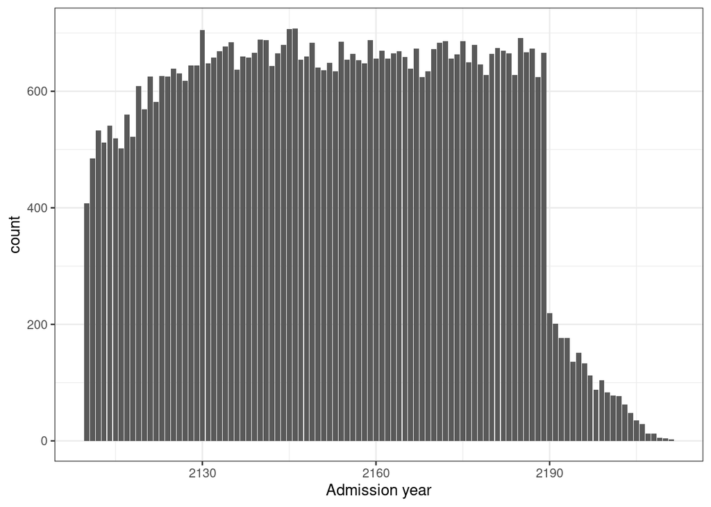

```r
admissions_tble %>%
  ggplot() +
  geom_bar(mapping = aes(x = year(admittime))) +
  labs(x="Admission year") +
  theme_bw()
```

- admission month

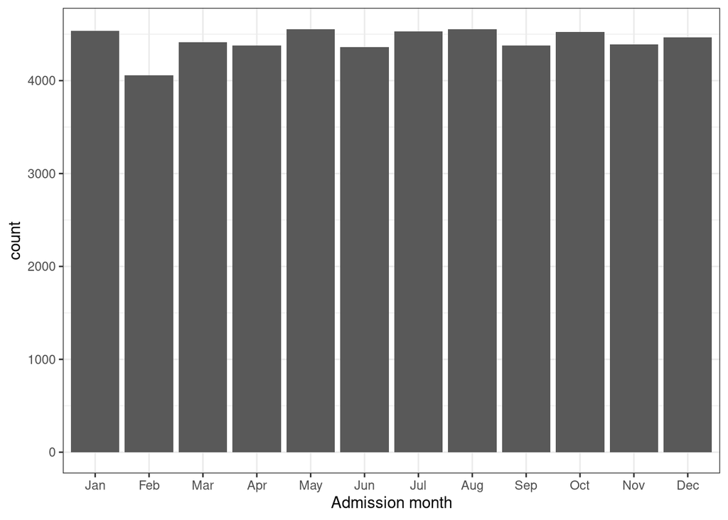

```r
admissions_tble %>%
  ggplot() +
  geom_bar(mapping = aes(x = lubridate::month(admittime, label = TRUE))) +
  labs(x="Admission month") +
  theme_bw()
```

- admission month day

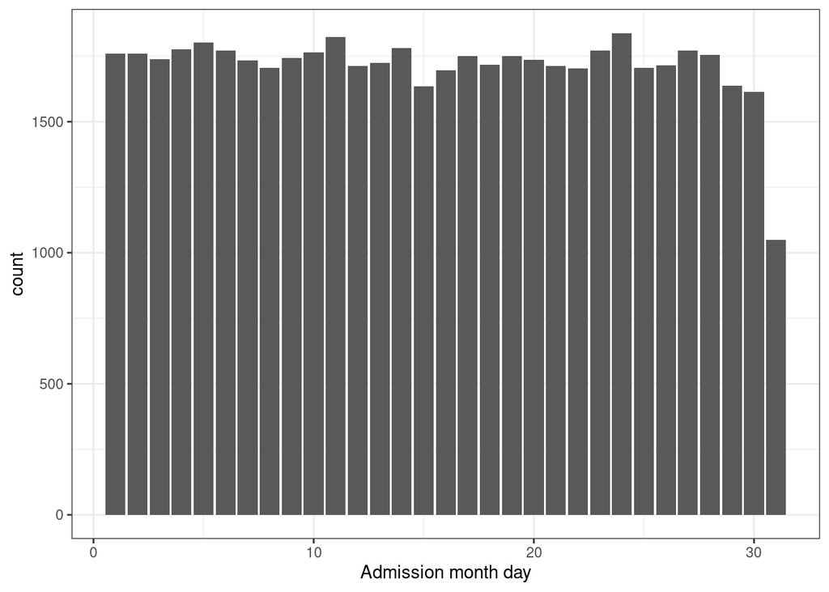

```r
admissions_tble %>%
  ggplot() +
  geom_bar(mapping = aes(x = mday(admittime))) +
  labs(x="Admission month day") +
  theme_bw()
```

- admission week day

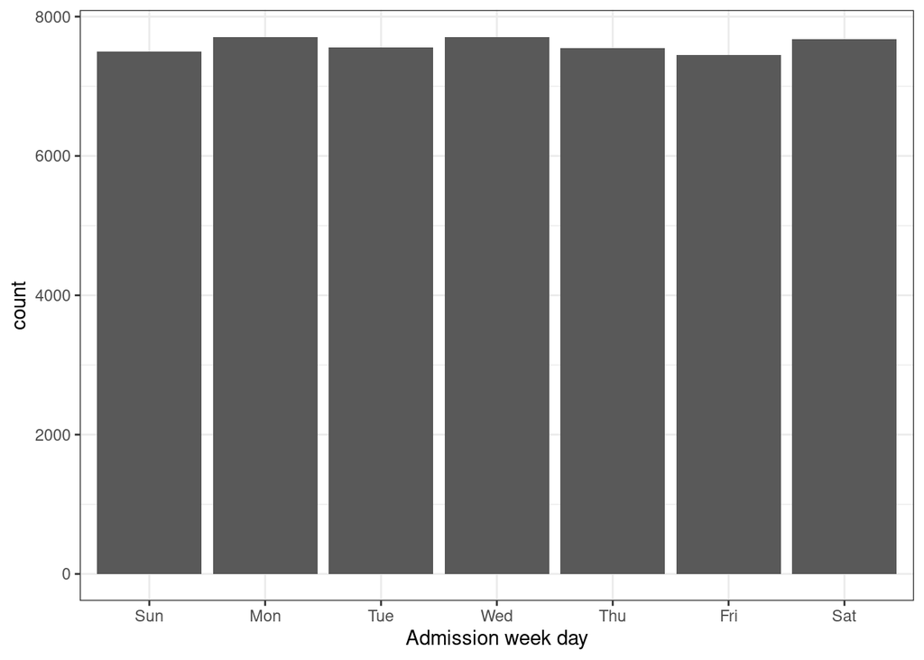

```r
admissions_tble %>%
  ggplot() +
  geom_bar(mapping = aes(x = lubridate::wday(admittime, label = TRUE))) +
  labs(x="Admission week day") +
  theme_bw()
```

- admission hour (anything unusual?)

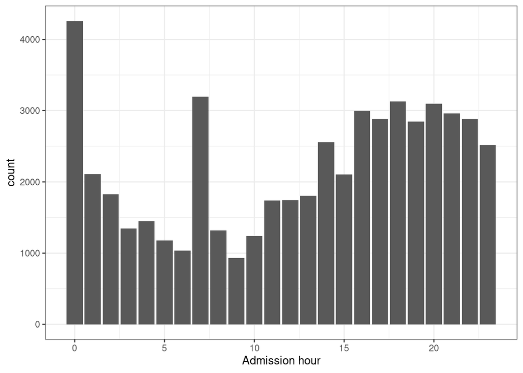

```r
admissions_tble %>%
  ggplot() +
  geom_bar(mapping = aes(x = hour(admittime))) +
  labs(x="Admission hour") +
  theme_bw()
```

*Extremely high number of admissions at hour 0. Also, we observe a peak at about 7 am, which is unusual.*

## Q4. `patients` data

Patient information is available in `patients.csv.gz`. See https://mimic.mit.edu/docs/iv/modules/core/patients/ for details of each field in this file. The first 10 lines are

```r
system(
  str_c(
    "zcat < ",
    shQuote(str_c(mimic_path, "/core/patients.csv.gz")),
    " | head"
    ),
  intern = TRUE
)
```

```
##  [1] "subject_id,gender,anchor_age,anchor_year,anchor_year_group,dod"
##  [2] "10000048,F,23,2126,2008 - 2010,"
##  [3] "10002723,F,0,2128,2017 - 2019,"
##  [4] "10003939,M,0,2184,2008 - 2010,"
##  [5] "10004222,M,0,2161,2014 - 2016,"
##  [6] "10005325,F,0,2154,2011 - 2013,"
##  [7] "10007338,F,0,2153,2017 - 2019,"
##  [8] "10008101,M,0,2142,2008 - 2010,"
##  [9] "10009872,F,0,2168,2014 - 2016,"
## [10] "10011333,F,0,2132,2014 - 2016,"
```

1. Import `patients.csv.gz` (https://mimic.mit.edu/docs/iv/modules/core/patients/) as a tibble `patients_tble` and only keep the patients who have a match in `icustays_tble` (according to `subject_id`).

```r
patients_tble <- read_csv("/mnt/mimiciv/1.0/core/patients.csv.gz",
                          show_col_types = FALSE) %>%
  as_tibble() %>%
  semi_join(icustays_tble, by = "subject_id") %>%
  print(width = Inf)
```

```
## # A tibble: 53,150 × 6
##    subject_id gender anchor_age anchor_year anchor_year_group dod
##         <dbl> <chr>       <dbl>       <dbl> <chr>             <date>
##  1   10018928 F              31        2125 2008 - 2010       NA
##  2   10076543 F              78        2187 2008 - 2010       NA
##  3   10098428 F              85        2119 2008 - 2010       NA
##  4   10127185 M              60        2141 2008 - 2010       NA
##  5   10148710 M              67        2137 2008 - 2010       NA
##  6   10156486 F              75        2124 2017 - 2019       NA
##  7   10159585 M              59        2146 2008 - 2010       2154-04-16
##  8   10171525 F              27        2115 2014 - 2016       NA
##  9   10196360 M              57        2118 2011 - 2013       NA
## 10   10227823 M              45        2156 2014 - 2016       NA
## # … with 53,140 more rows
```

2. Summarize variables `gender` and `anchor_age`, and explain any patterns you see.

```r
table(patients_tble$gender)
```

```
##
##     F     M
## 23353 29797
```

```r
summarise(patients_tble, mean = mean(anchor_age))
```

```
## # A tibble: 1 × 1
##    mean
##   <dbl>
## 1  63.5
```

```r
patients_tble %>%
  group_by(gender) %>%
  summarise(mean = mean(anchor_age)) %>%
  ungroup()
```

```
## # A tibble: 2 × 2
##   gender  mean
##   <chr>  <dbl>
## 1 F       64.8
## 2 M       62.5
```

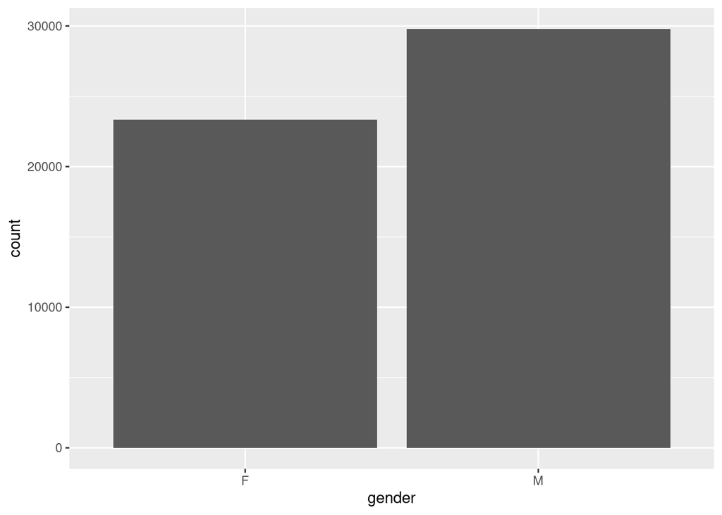

```r
patients_tble %>%
  ggplot() +
  geom_bar(mapping = aes(x = gender))
```

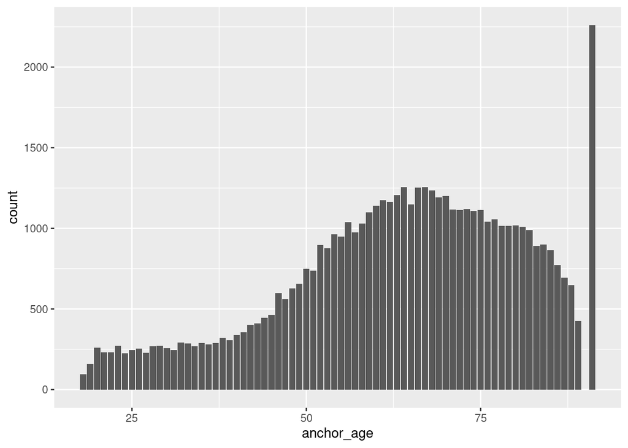

```r
patients_tble %>%
  ggplot() +
  geom_bar(mapping = aes(x = anchor_age))
```

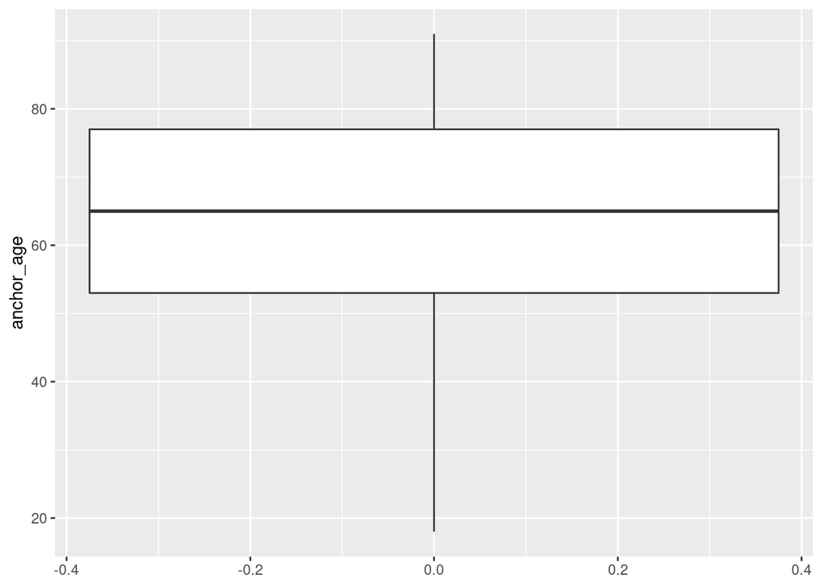

```r
patients_tble %>%
  ggplot() +
  geom_boxplot(mapping = aes(y = anchor_age))
```

*There is a higher proportion of male patients. The average anchor age of the patients is 63.5. The distribution of the anchor age is slightly left-skewed. Females have a higher average anchor age than males.*

## Q5. Lab results

`labevents.csv.gz` (https://mimic.mit.edu/docs/iv/modules/hosp/labevents/) contains all laboratory measurements for patients. The first 10 lines are

```r
system(
  str_c(
    "zcat < ",
    shQuote(str_c(mimic_path, "/hosp/labevents.csv.gz")),
    " | head"
    ),
  intern = TRUE
)
```

```
##  [1] "labevent_id,subject_id,hadm_id,specimen_id,itemid,charttime,storetime,value,valuenum,valueuom,ref_range_lower,ref_range_upper,flag,priority,comments"
##  [2] "670,10000048,,6448755,51484,2126-11-22 19:20:00,2126-11-22 20:07:00,150,150,mg/dL,,,,STAT,"
##  [3] "673,10000048,,6448755,51491,2126-11-22 19:20:00,2126-11-22 20:07:00,6.5,6.5,units,5,8,,STAT,"
##  [4] "675,10000048,,6448755,51498,2126-11-22 19:20:00,2126-11-22 20:07:00,1.029,1.029, ,1.001,1.035,,STAT,"
##  [5] "683,10000048,,82729055,50861,2126-11-22 20:45:00,2126-11-23 00:55:00,39,39,IU/L,0,40,,STAT,"
##  [6] "684,10000048,,82729055,50862,2126-11-22 20:45:00,2126-11-23 00:55:00,4.7,4.7,g/dL,3.4,4.8,,STAT,"
##  [7] "685,10000048,,82729055,50863,2126-11-22 20:45:00,2126-11-23 00:55:00,45,45,IU/L,39,117,,STAT,"
##  [8] "686,10000048,,82729055,50868,2126-11-22 20:45:00,2126-11-22 21:32:00,13,13,mEq/L,8,20,,STAT,"
##  [9] "687,10000048,,82729055,50878,2126-11-22 20:45:00,2126-11-23 00:55:00,28,28,IU/L,0,40,,STAT,"
## [10] "688,10000048,,82729055,50882,2126-11-22 20:45:00,2126-11-22 21:32:00,26,26,mEq/L,22,32,,STAT,"
```

`d_labitems.csv.gz` is the dictionary of lab measurements.

```r
system(
  str_c(
    "zcat < ",
    shQuote(str_c(mimic_path, "/hosp/d_labitems.csv.gz")),
    " | head"
    ),
  intern = TRUE
)
```

```
##  [1] "itemid,label,fluid,category,loinc_code"
##  [2] "51905, ,Other Body Fluid,Chemistry,"
##  [3] "51532,11-Deoxycorticosterone,Blood,Chemistry,"
##  [4] "51957,17-Hydroxycorticosteroids,Urine,Chemistry,"
##  [5] "51958,\"17-Ketosteroids, Urine\",Urine,Chemistry,"
##  [6] "52068,24 Hr,Blood,Hematology,"
##  [7] "51066,24 hr Calcium,Urine,Chemistry,"
##  [8] "51067,24 hr Creatinine,Urine,Chemistry,"
##  [9] "51068,24 hr Protein,Urine,Chemistry,"
## [10] "50853,25-OH Vitamin D,Blood,Chemistry,"
```

1. Find how many rows are in `labevents.csv.gz`.

```r
count(read_csv("/mnt/mimiciv/1.0/hosp/labevents_filtered_itemid.csv.gz",
               show_col_types = FALSE))
```

```
## # A tibble: 1 × 1
##          n
##      <int>
## 1 30198826
```

```r
#nrow(read_csv("/mnt/mimiciv/1.0/hosp/labevents_filtered_itemid.csv.gz",
#              show_col_types = FALSE))
```

*There are 30198826 rows in `labevents_filtered_itemid.csv.gz`.*

```r
system(
  str_c(
    "gzip < ",
    shQuote(str_c(mimic_path, "/hosp/labevents.csv.gz")),
    " | wc -l"
    ),
  intern = TRUE
)
```

```
## [1] "7961709"
```

2. We are interested in the lab measurements of creatinine (50912), potassium (50971), sodium (50983), chloride (50902), bicarbonate (50882), hematocrit (51221), white blood cell count (51301), glucose (50931), magnesium (50960), and calcium (50893). Retrieve a subset of `labevents.csv.gz` only containing these items for the patients in `icustays_tble` as a tibble `labevents_tble`.

   Hint: `labevents.csv.gz` is a data file too big to be read in by the `read_csv` function in its default setting. Utilize the `col_select` and `lazy` options in the `read_csv` function to reduce the memory burden.

```r
dlabitems_tble <- read_csv("/mnt/mimiciv/1.0/hosp/d_labitems.csv.gz",
                           show_col_types = FALSE) %>%
  filter(itemid %in% c(50912,
                       50971,
                       50983,
                       50902,
                       50882,
                       51221,
                       51301,
                       50931,
                       50960,
                       50893))


labevents_tble <-
  read_csv("/mnt/mimiciv/1.0/hosp/labevents_filtered_itemid.csv.gz",
           show_col_types = FALSE) %>%
  as_tibble() %>%
  semi_join(icustays_tble, by = "subject_id") %>%
  filter(itemid %in% dlabitems_tble$itemid)
```

3. Further restrict `labevents_tble` to the first lab measurement during the ICU stay.

```r
labevents_tble <-
  labevents_tble %>%
  left_join(select(icustays_tble, subject_id, intime),
            by = c("subject_id")) %>%
  filter(charttime >= intime) %>%
  group_by(subject_id, itemid) %>%
    arrange(charttime, .by_group = TRUE) %>%
  slice_head(n = 1) %>%
  select(-charttime, -intime) %>%
  ungroup() %>%
  pivot_wider(names_from = itemid, values_from = valuenum) %>%
  rename_at(
    vars(as.character(dlabitems_tble$itemid)),
    ~str_to_lower(dlabitems_tble$label)
  ) %>%
  rename(wbc = 'white blood cells', calcium = 'calcium, total') %>%
  print(width = Inf)
```

```
## # A tibble: 52,544 × 11
##    subject_id bicarbonate calcium chloride creatinine glucose magnesium
##         <dbl>       <dbl>   <dbl>    <dbl>      <dbl>   <dbl>     <dbl>
##  1   10000032          21     9.3      102        0.5     115       2.3
##  2   10000980          23     9.2      103        2.2     144       2
##  3   10001217          23     8.2      104        0.4     113       1.9
##  4   10001725          24     9.1      106        0.8     146       1.5
##  5   10001884          33     9.8       96        1.1     148       2.2
##  6   10002013          23     8.2      109        1.1      98       2.1
##  7   10002155          25     8.8      106        0.9      95       2
##  8   10002223          26     8.7      102        0.8      88       2
##  9   10002348          23     9.4      107        0.8     127       1.6
## 10   10002428          20     7.4       98        0.8      99       1.4
##    potassium sodium hematocrit   wbc
##        <dbl>  <dbl>      <dbl> <dbl>
##  1       4.7    132       34.8   4.1
##  2       4.2    139       30.8   5.4
##  3       3.6    138       33.6  19
##  4       3.9    140       39.1  17
##  5       4      136       36    18.4
##  6       4      140       28.6  18.2
##  7       4.5    139       37.9   5.5
##  8       3.9    138       32.5  10.1
##  9       4.8    142       39.3   4.3
## 10       3.9    129       28.7  22.4
## # … with 52,534 more rows
```

4. Summarize the lab measurements by appropriate numerics and graphics.

```r
summary(labevents_tble)
```

```
##    subject_id        bicarbonate       calcium          chloride
##  Min.   :10000032   Min.   : 2.00   Min.   : 0.000   Min.   : 58.0
##  1st Qu.:12481897   1st Qu.:21.00   1st Qu.: 7.900   1st Qu.:101.0
##  Median :14990408   Median :23.00   Median : 8.400   Median :105.0
##  Mean   :14989147   Mean   :23.01   Mean   : 8.366   Mean   :104.5
##  3rd Qu.:17497556   3rd Qu.:25.00   3rd Qu.: 8.900   3rd Qu.:108.0
##  Max.   :19999987   Max.   :49.00   Max.   :43.000   Max.   :153.0
##                     NA's   :119     NA's   :1241     NA's   :96
##    creatinine        glucose       magnesium        potassium
##  Min.   : 0.000   Min.   :   7   Min.   : 0.000   Min.   : 0.800
##  1st Qu.: 0.700   1st Qu.: 103   1st Qu.: 1.700   1st Qu.: 3.700
##  Median : 0.900   Median : 124   Median : 2.000   Median : 4.100
##  Mean   : 1.307   Mean   : 141   Mean   : 2.002   Mean   : 4.176
##  3rd Qu.: 1.300   3rd Qu.: 156   3rd Qu.: 2.200   3rd Qu.: 4.500
##  Max.   :36.900   Max.   :2440   Max.   :47.000   Max.   :13.000
##  NA's   :87       NA's   :107    NA's   :258      NA's   :115
##      sodium        hematocrit         wbc
##  Min.   : 92.0   Min.   : 4.30   Min.   :  0.00
##  1st Qu.:136.0   1st Qu.:28.10   1st Qu.:  7.60
##  Median :139.0   Median :32.70   Median : 10.50
##  Mean   :138.5   Mean   :32.79   Mean   : 12.01
##  3rd Qu.:141.0   3rd Qu.:37.30   3rd Qu.: 14.40
##  Max.   :180.0   Max.   :68.60   Max.   :572.50
##  NA's   :84      NA's   :292     NA's   :292
```

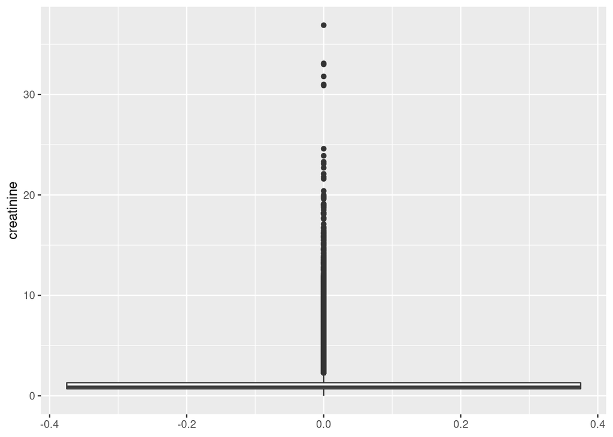

```r
labevents_tble %>%
  ggplot() +
  geom_boxplot(mapping = aes(y = creatinine), na.rm = TRUE)
```

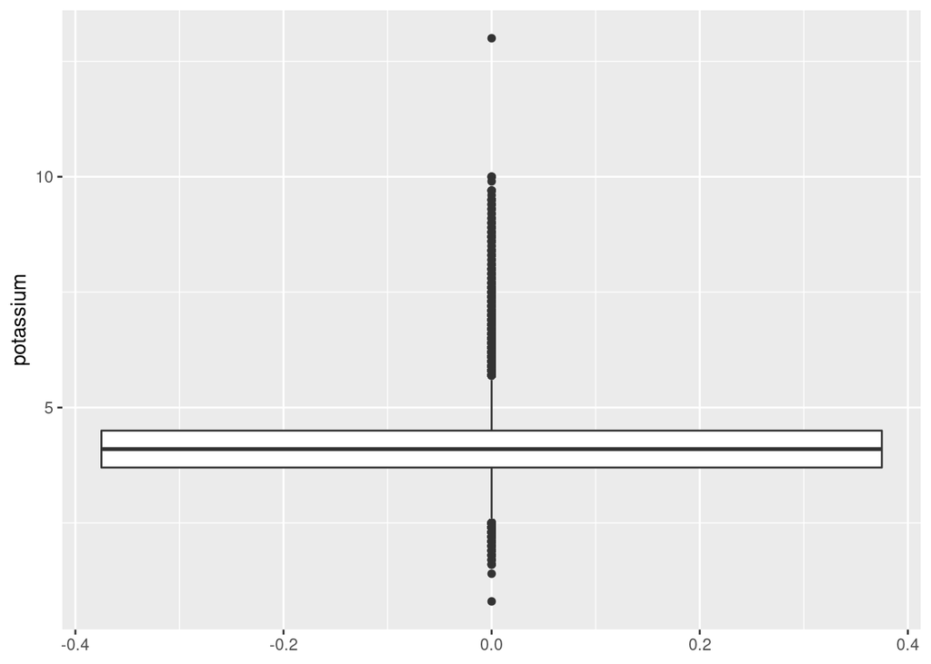

```r
labevents_tble %>%
  ggplot() +
  geom_boxplot(mapping = aes(y = potassium), na.rm = TRUE)
```

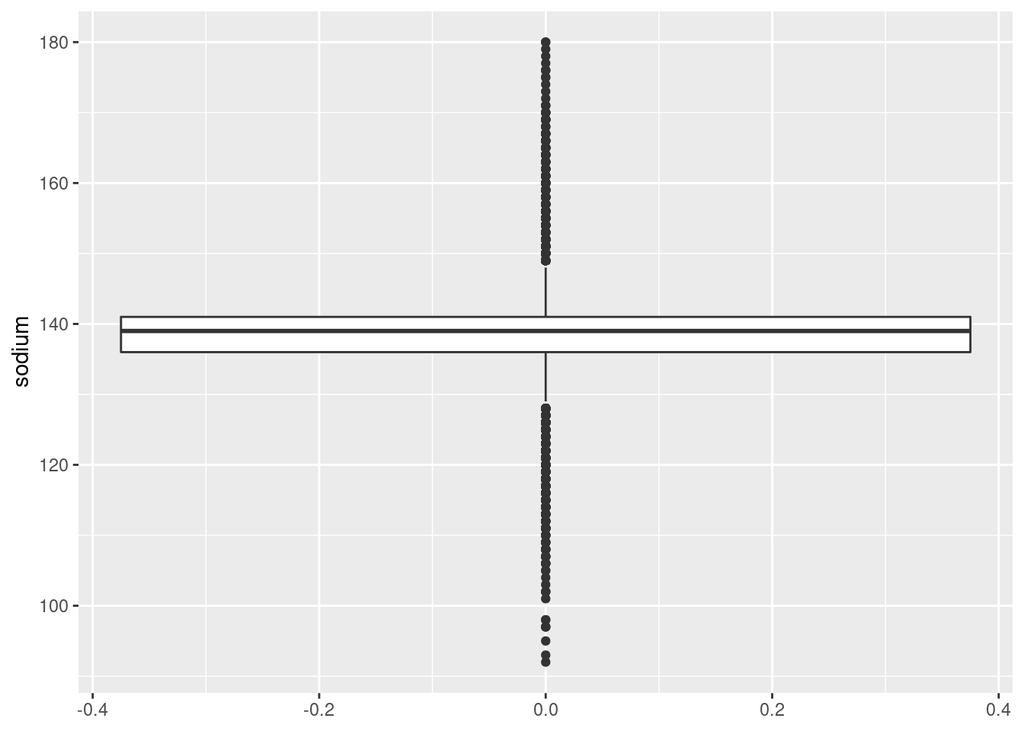

```r
labevents_tble %>%
  ggplot() +
  geom_boxplot(mapping = aes(y = sodium), na.rm = TRUE)
```

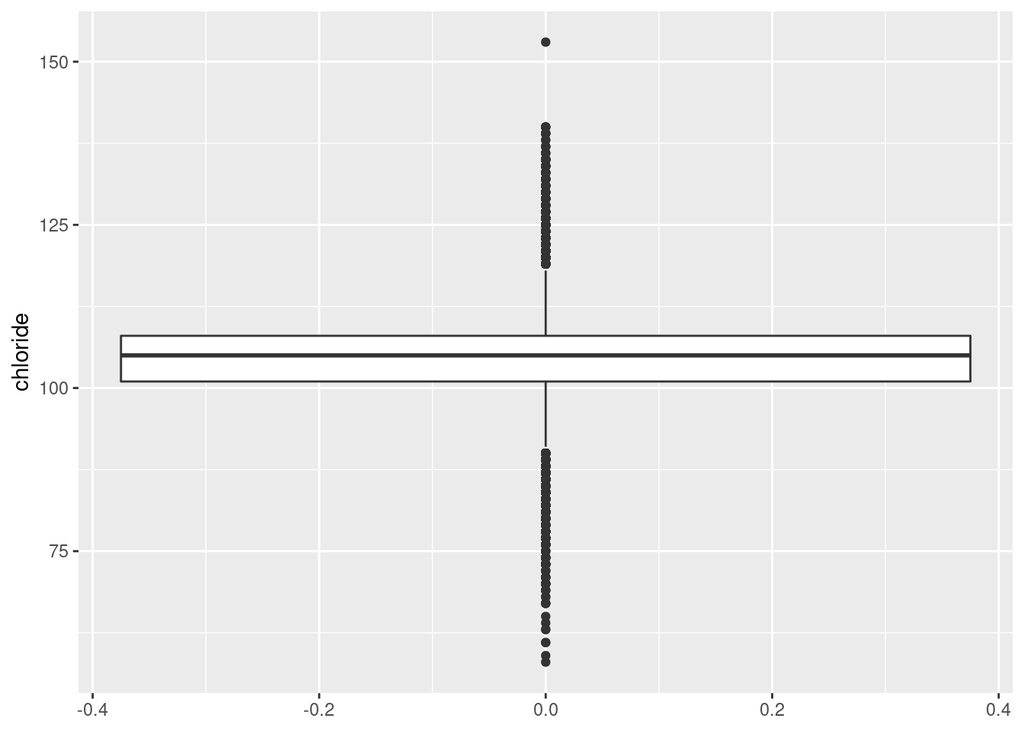

```r
labevents_tble %>%
  ggplot() +
  geom_boxplot(mapping = aes(y = chloride), na.rm = TRUE)
```

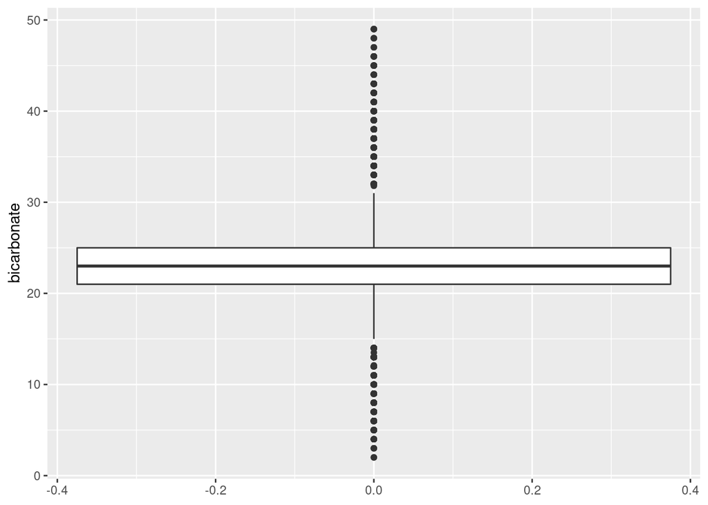

```r
labevents_tble %>%
  ggplot() +
  geom_boxplot(mapping = aes(y = bicarbonate), na.rm = TRUE)
```

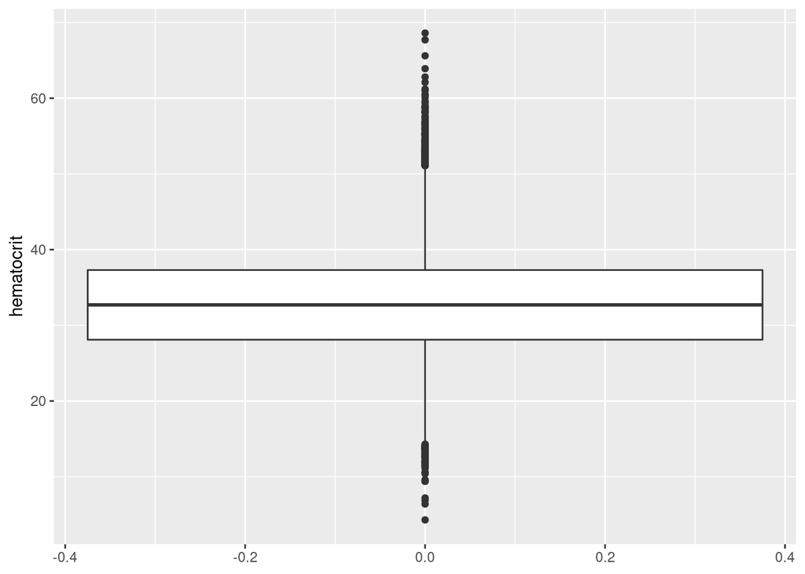

```r
labevents_tble %>%
  ggplot() +
  geom_boxplot(mapping = aes(y = hematocrit), na.rm = TRUE)
```

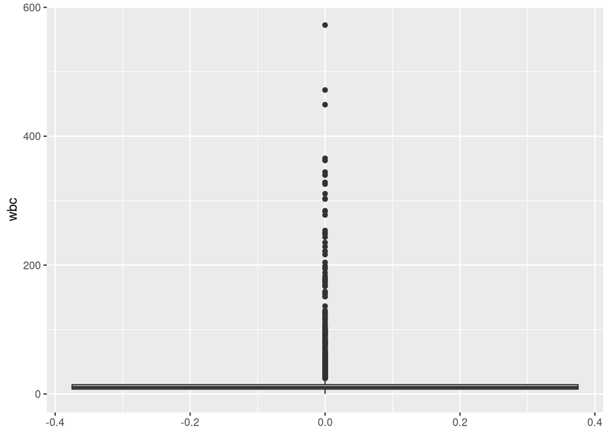

```r
labevents_tble %>%
  ggplot() +
  geom_boxplot(mapping = aes(y = wbc), na.rm = TRUE)
```

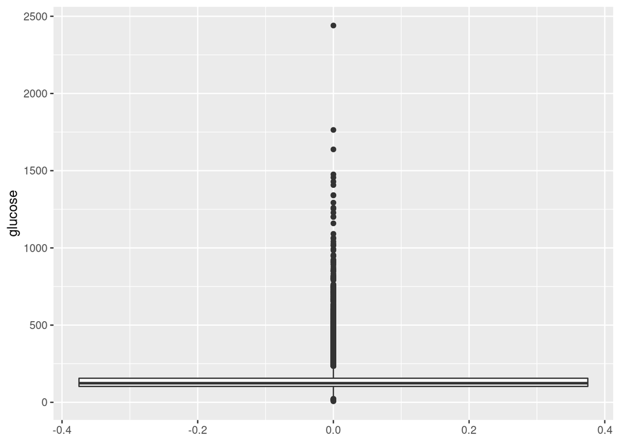

```r
labevents_tble %>%
  ggplot() +
  geom_boxplot(mapping = aes(y = glucose), na.rm = TRUE)
```

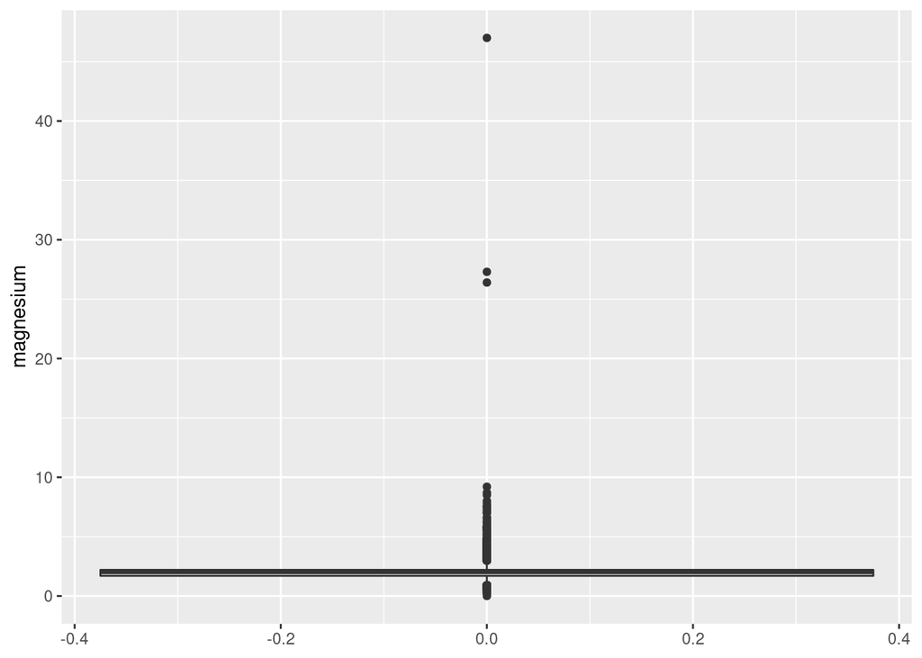

```r
labevents_tble %>%
  ggplot() +
  geom_boxplot(mapping = aes(y = magnesium), na.rm = TRUE)
```

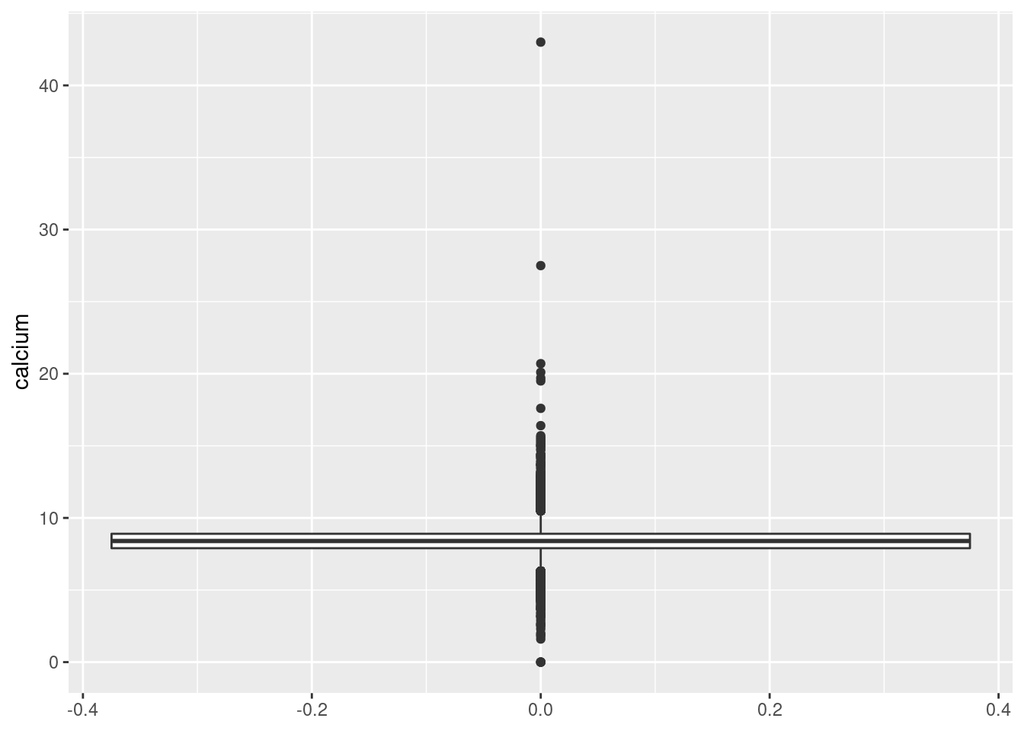

```r
labevents_tble %>%
  ggplot() +
  geom_boxplot(mapping = aes(y = calcium), na.rm = TRUE)
```

## Q6. Vitals from charted events

`chartevents.csv.gz` (https://mimic.mit.edu/docs/iv/modules/icu/chartevents/) contains all the charted data available for a patient. During their ICU stay, the primary repository of a patient’s information is their electronic chart. The `itemid` variable indicates a single measurement type in the database. The `value` variable is the value measured for `itemid`. The first 10 lines of `chartevents.csv.gz` are

```r
system(
  str_c(
    "zcat < ",
    shQuote(str_c(mimic_path, "/icu/chartevents.csv.gz")),
    " | head"),
  intern = TRUE
)
```

```
##  [1] "subject_id,hadm_id,stay_id,charttime,storetime,itemid,value,valuenum,valueuom,warning"
##  [2] "10003700,28623837,30600691,2165-04-24 05:10:00,2165-04-24 05:11:00,228236,0,0,,0"
##  [3] "10003700,28623837,30600691,2165-04-24 05:12:00,2165-04-24 05:14:00,225067,0,0,,0"
##  [4] "10003700,28623837,30600691,2165-04-24 05:12:00,2165-04-24 05:14:00,225070,1,1,,0"
##  [5] "10003700,28623837,30600691,2165-04-24 05:12:00,2165-04-24 05:14:00,225076,1,1,,0"
##  [6] "10003700,28623837,30600691,2165-04-24 05:12:00,2165-04-24 05:14:00,225078,1,1,,0"
##  [7] "10003700,28623837,30600691,2165-04-24 05:12:00,2165-04-24 05:14:00,225086,1,1,,0"
##  [8] "10003700,28623837,30600691,2165-04-24 05:12:00,2165-04-24 05:14:00,225091,1,1,,0"
##  [9] "10003700,28623837,30600691,2165-04-24 05:12:00,2165-04-24 05:14:00,225103,1,1,,0"
## [10] "10003700,28623837,30600691,2165-04-24 05:12:00,2165-04-24 05:14:00,225106,1,1,,0"
```

`d_items.csv.gz` (https://mimic.mit.edu/docs/iv/modules/icu/d_items/) is the dictionary for the `itemid` in `chartevents.csv.gz`.

```r
system(
  str_c(
    "zcat < ",
    shQuote(str_c(mimic_path, "/icu/d_items.csv.gz")),
    " | head"),
  intern = TRUE
)
```

```
##  [1] "itemid,label,abbreviation,linksto,category,unitname,param_type,lownormalvalue,highnormalvalue"
##  [2] "220003,ICU Admission date,ICU Admission date,datetimeevents,ADT,,Date and time,,"
##  [3] "220045,Heart Rate,HR,chartevents,Routine Vital Signs,bpm,Numeric,,"
##  [4] "220046,Heart rate Alarm - High,HR Alarm - High,chartevents,Alarms,bpm,Numeric,,"
##  [5] "220047,Heart Rate Alarm - Low,HR Alarm - Low,chartevents,Alarms,bpm,Numeric,,"
##  [6] "220048,Heart Rhythm,Heart Rhythm,chartevents,Routine Vital Signs,,Text,,"
##  [7] "220050,Arterial Blood Pressure systolic,ABPs,chartevents,Routine Vital Signs,mmHg,Numeric,90,140"
##  [8] "220051,Arterial Blood Pressure diastolic,ABPd,chartevents,Routine Vital Signs,mmHg,Numeric,60,90"
##  [9] "220052,Arterial Blood Pressure mean,ABPm,chartevents,Routine Vital Signs,mmHg,Numeric,,"
## [10] "220056,Arterial Blood Pressure Alarm - Low,ABP Alarm - Low,chartevents,Alarms,mmHg,Numeric,,"
```

1. We are interested in the vitals for ICU patients: heart rate (220045), mean non-invasive blood pressure (220181), systolic non-invasive blood pressure (220179), body temperature in Fahrenheit (223761), and respiratory rate (220210). Retrieve a subset of `chartevents.csv.gz` only containing these items for the patients in `icustays_tble` as a tibble `chartevents_tble`.

```r
ditems_tble <- read_csv("/mnt/mimiciv/1.0/icu/d_items.csv.gz",
                        show_col_types = FALSE) %>%
  filter(itemid %in% c(220045,
                       220181,
                       220179,
                       223761,
                       220210))

chartevents_tble <-
  read_csv("/mnt/mimiciv/1.0/icu/chartevents_filtered_itemid.csv.gz",
           show_col_types = FALSE) %>%
  as_tibble() %>%
  semi_join(icustays_tble, by = "subject_id") %>%
  filter(itemid %in% ditems_tble$itemid)
```

2. Further restrict `chartevents_tble` to the first vital measurement during the ICU stay.

```r
chartevents_tble <- chartevents_tble %>%
  left_join(select(icustays_tble, subject_id, intime),
            by = c("subject_id")) %>%
  filter(charttime >= intime) %>%
  group_by(subject_id, itemid) %>%
    arrange(charttime, .by_group = TRUE) %>%
  slice_head(n = 1) %>%
  select(-charttime, -intime) %>%
  ungroup() %>%
  pivot_wider(names_from = itemid, values_from = valuenum) %>%
  rename_at(
    vars(as.character(ditems_tble$itemid)),
    ~str_to_lower(ditems_tble$label)
  ) %>%
  rename(heartrate = 'heart rate',
         sbp = 'non invasive blood pressure systolic',
         meanbp = 'non invasive blood pressure mean',
         resp_rate= 'respiratory rate',
         temp = 'temperature fahrenheit') %>%
  print(width = Inf)
```

```
## # A tibble: 53,407 × 8
##    subject_id  hadm_id  stay_id heartrate   sbp meanbp resp_rate  temp
##         <dbl>    <dbl>    <dbl>     <dbl> <dbl>  <dbl>     <dbl> <dbl>
##  1   10000032 29079034 39553978        91    84     56        24  98.7
##  2   10000980 26913865 39765666        77   150     92        23  98
##  3   10001217 24597018 37067082        86   151    104        18  98.5
##  4   10001725 25563031 31205490        55    73     59        19  97.7
##  5   10001884 26184834 37510196        38   180     46        10  98.1
##  6   10002013 23581541 39060235        80   104     77        14  97.2
##  7   10002155 23822395 33685454        68   126     78        18  95.9
##  8   10002223 22494570 39638202       100   123     80        29  98.6
##  9   10002348 22725460 32610785        72   129     85        14  97.9
## 10   10002428 28662225 33987268       124    87     53        25 103.
## # … with 53,397 more rows
```

3. Summarize these vital measurements by appropriate numerics and graphics.

```r
summary(chartevents_tble)
```

```
##    subject_id          hadm_id            stay_id           heartrate
##  Min.   :10000032   Min.   :20000094   Min.   :30000153   Min.   :  0.00
##  1st Qu.:12483096   1st Qu.:22480092   1st Qu.:32466580   1st Qu.: 74.00
##  Median :14992360   Median :24952624   Median :34985627   Median : 85.00
##  Mean   :14989969   Mean   :24978282   Mean   :34984209   Mean   : 87.47
##  3rd Qu.:17497644   3rd Qu.:27483142   3rd Qu.:37487506   3rd Qu.: 99.00
##  Max.   :19999987   Max.   :29999828   Max.   :39999810   Max.   :941.00
##                                                           NA's   :258
##       sbp              meanbp            resp_rate           temp
##  Min.   :    0.0   Min.   :     0.00   Min.   :  0.00   Min.   :  0.00
##  1st Qu.:  106.0   1st Qu.:    70.00   1st Qu.: 15.00   1st Qu.: 97.60
##  Median :  122.0   Median :    81.00   Median : 18.00   Median : 98.10
##  Mean   :  123.8   Mean   :    87.39   Mean   : 18.69   Mean   : 98.03
##  3rd Qu.:  139.0   3rd Qu.:    93.00   3rd Qu.: 22.00   3rd Qu.: 98.70
##  Max.   :12262.0   Max.   :140119.00   Max.   :180.00   Max.   :106.00
##  NA's   :769       NA's   :790         NA's   :294      NA's   :1077
```

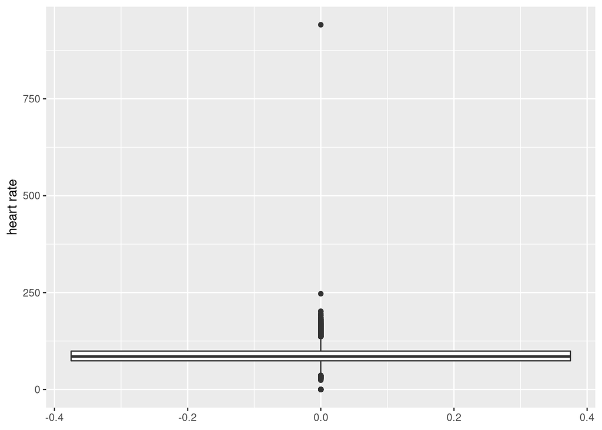

```r
chartevents_tble %>%
  ggplot() +
  geom_boxplot(mapping = aes(y = heartrate), na.rm = TRUE) +
  labs(y = "heart rate")
```

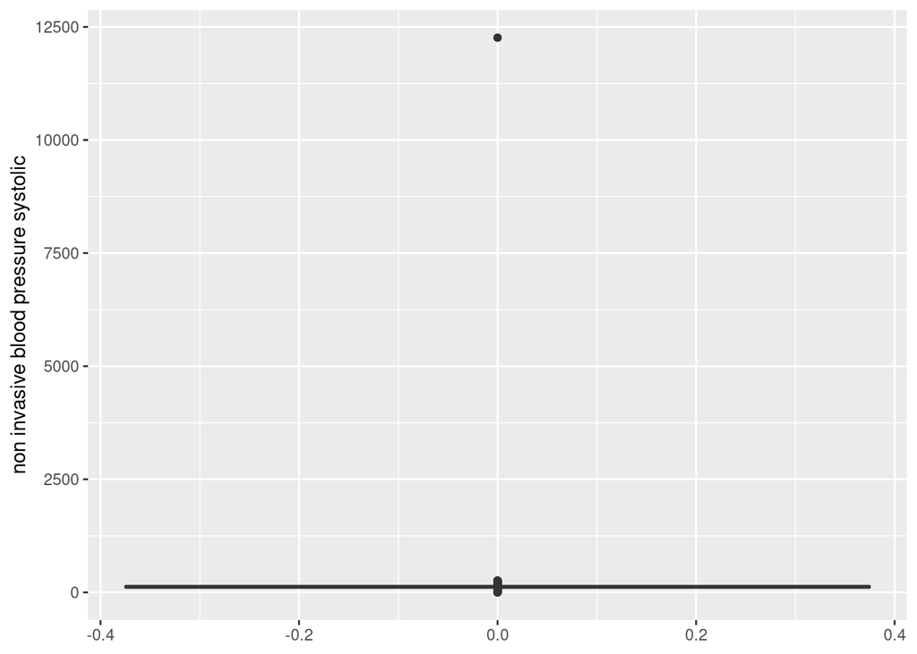

```r
chartevents_tble %>%
  ggplot() +
  geom_boxplot(mapping = aes(y = sbp), na.rm = TRUE) +
  labs(y = "non invasive blood pressure systolic")
```

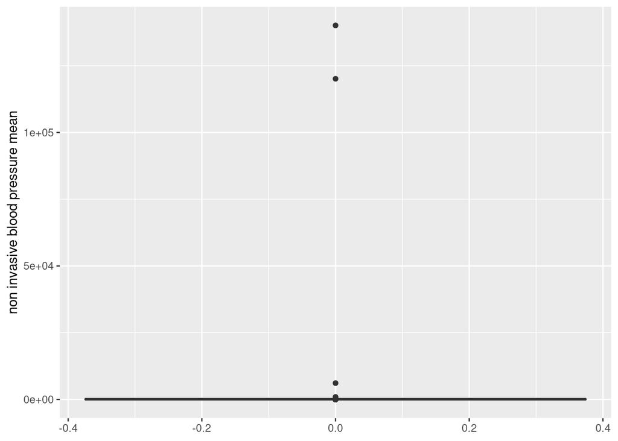

```r
chartevents_tble %>%
  ggplot() +
  geom_boxplot(mapping = aes(y = meanbp), na.rm = TRUE) +
  labs(y = "non invasive blood pressure mean")
```

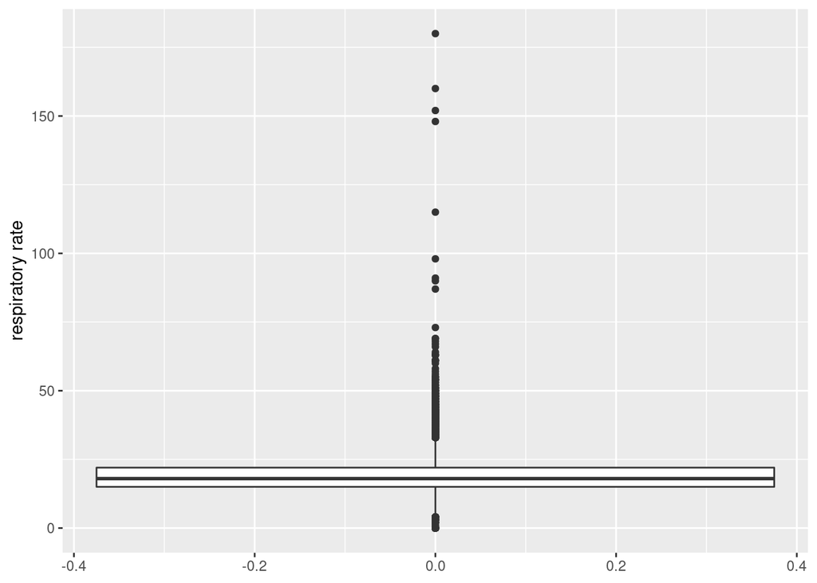

```r
chartevents_tble %>%
  ggplot() +
  geom_boxplot(mapping = aes(y = resp_rate), na.rm = TRUE) +
  labs(y = "respiratory rate")
```

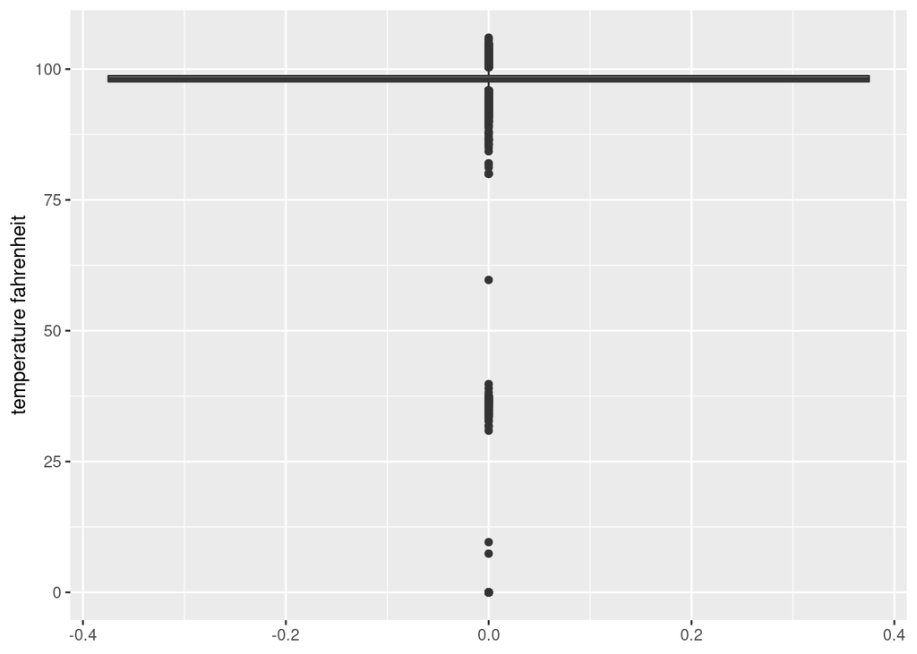

```r
chartevents_tble %>%
  ggplot() +
  geom_boxplot(mapping = aes(y = temp), na.rm = TRUE) +
  labs(y = "temperature fahrenheit")
```

## Q7. Putting things together

Let us create a tibble `mimic_icu_cohort` for all ICU stays, where rows are

- first ICU stay of each unique adult (age at admission > 18)

and columns contain at least following variables

- all variables in `icustays.csv.gz`
- all variables in `admission.csv.gz`
- all variables in `patients.csv.gz`
- first lab measurements during ICU stay
- first vital measurements during ICU stay
- an indicator variable `thirty_day_mort` whether the patient died within 30 days of hospital admission (30 day mortality)

```r
mimic_icu_cohort <-
  icustays_tble %>%
  left_join(admissions_tble, by = c("subject_id", "hadm_id")) %>%
  left_join(patients_tble, by = "subject_id") %>%
  left_join(labevents_tble, by = "subject_id") %>%
  left_join(chartevents_tble, by = c("stay_id", "subject_id", "hadm_id")) %>%
  mutate(age_hadm = anchor_age + year(admittime) - anchor_year) %>%
  filter(age_hadm > 18) %>%
  mutate(hadm_to_death = ifelse(is.na(deathtime),
                                Inf, deathtime-admittime)) %>%
  mutate(thirty_day_mort = hadm_to_death <= 2592000) %>%
  print(width = Inf)
```

```
## # A tibble: 53,065 × 44
##    subject_id  hadm_id  stay_id first_careunit
##         <dbl>    <dbl>    <dbl> <chr>
##  1   10000032 29079034 39553978 Medical Intensive Care Unit (MICU)
##  2   10000980 26913865 39765666 Medical Intensive Care Unit (MICU)
##  3   10001217 24597018 37067082 Surgical Intensive Care Unit (SICU)
##  4   10001725 25563031 31205490 Medical/Surgical Intensive Care Unit (MICU/SICU)
##  5   10001884 26184834 37510196 Medical Intensive Care Unit (MICU)
##  6   10002013 23581541 39060235 Cardiac Vascular Intensive Care Unit (CVICU)
##  7   10002155 23822395 33685454 Coronary Care Unit (CCU)
##  8   10002223 22494570 39638202 Trauma SICU (TSICU)
##  9   10002348 22725460 32610785 Neuro Intermediate
## 10   10002428 28662225 33987268 Medical Intensive Care Unit (MICU)
##    last_careunit                                    intime
##    <chr>                                            <dttm>
```

[output cut: 107 more lines]

## Q8. Exploratory data analysis (EDA)

Summarize following information using appropriate numerics or graphs.

```r
summary(mimic_icu_cohort)
```

```
##    subject_id          hadm_id            stay_id         first_careunit
##  Min.   :10000032   Min.   :20000094   Min.   :30000153   Length:53065
##  1st Qu.:12483898   1st Qu.:22478093   1st Qu.:32467111   Class :character
##  Median :14991424   Median :24947644   Median :34987214   Mode  :character
##  Mean   :14989837   Mean   :24975852   Mean   :34984050
##  3rd Qu.:17495811   3rd Qu.:27477277   3rd Qu.:37487113
##  Max.   :19999987   Max.   :29999828   Max.   :39999810
##
##  last_careunit          intime                       outtime
##  Length:53065       Min.   :2110-01-11 10:16:06   Min.   :2110-01-12 17:17:47
##  Class :character   1st Qu.:2132-11-05 21:29:00   1st Qu.:2132-11-07 16:56:01
##  Mode  :character   Median :2152-09-29 21:13:55   Median :2152-10-03 19:16:01
##                     Mean   :2152-10-28 03:05:41   Mean   :2152-10-31 11:49:07
##                     3rd Qu.:2172-11-04 17:18:32   3rd Qu.:2172-11-06 10:29:59
##                     Max.   :2211-05-01 06:59:19   Max.   :2211-05-10 22:51:06
##
##       los              admittime
##  Min.   :  0.00125   Min.   :2110-01-11 10:14:00
##  1st Qu.:  1.08575   1st Qu.:2132-11-03 21:46:00
##  Median :  1.87755   Median :2152-09-28 20:40:00
##  Mean   :  3.36349   Mean   :2152-10-27 02:08:14
##  3rd Qu.:  3.54231   3rd Qu.:2172-11-04 12:57:00
##  Max.   :110.23228   Max.   :2211-05-01 06:57:00
##
##    dischtime                     deathtime                   admission_type
##  Min.   :2110-01-15 17:31:00   Min.   :2110-01-25 09:40:00   Length:53065
##  1st Qu.:2132-11-14 16:40:00   1st Qu.:2132-07-10 07:00:00   Class :character
##  Median :2152-10-07 17:00:00   Median :2152-02-27 00:01:00   Mode  :character
##  Mean   :2152-11-05 12:22:14   Mean   :2152-05-26 08:36:13
##  3rd Qu.:2172-11-10 14:55:00   3rd Qu.:2172-05-05 03:35:00
##  Max.   :2211-05-12 17:54:00   Max.   :2211-01-17 12:34:00
##                                NA's   :47558
##  admission_location discharge_location  insurance           language
##  Length:53065       Length:53065       Length:53065       Length:53065
##  Class :character   Class :character   Class :character   Class :character
##  Mode  :character   Mode  :character   Mode  :character   Mode  :character
##
##
##
##
```

[output cut: 49 more lines]

```
##  Min.   :     0.00   Min.   :  0.00   Min.   :  0.00   Min.   : 19.00
##  1st Qu.:    70.00   1st Qu.: 15.00   1st Qu.: 97.60   1st Qu.: 54.00
##  Median :    81.00   Median : 18.00   Median : 98.10   Median : 66.00
##  Mean   :    87.43   Mean   : 18.69   Mean   : 98.03   Mean   : 64.54
##  3rd Qu.:    93.00   3rd Qu.: 22.00   3rd Qu.: 98.70   3rd Qu.: 78.00
##  Max.   :140119.00   Max.   :180.00   Max.   :106.00   Max.   :102.00
##  NA's   :699         NA's   :59       NA's   :947
##  hadm_to_death   thirty_day_mort
##  Min.   :-1361   Mode :logical
##  1st Qu.:  Inf   FALSE:47558
##  Median :  Inf   TRUE :5507
##  Mean   :  Inf
##  3rd Qu.:  Inf
##  Max.   :  Inf
##
```

```r
#head(mimic_icu_cohort)
```

*30 day mortality vs ethnicity*

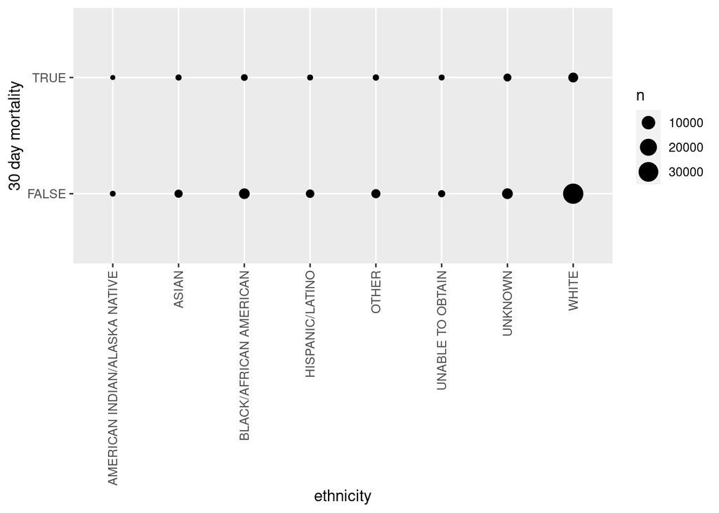

```r
mimic_icu_cohort %>%
  ggplot() +
  geom_count(mapping = aes(x = ethnicity, y = thirty_day_mort)) +
  theme(axis.text.x = element_text(angle = 90, vjust = 0.5, hjust = 1)) +
  labs(y = "30 day mortality")
```

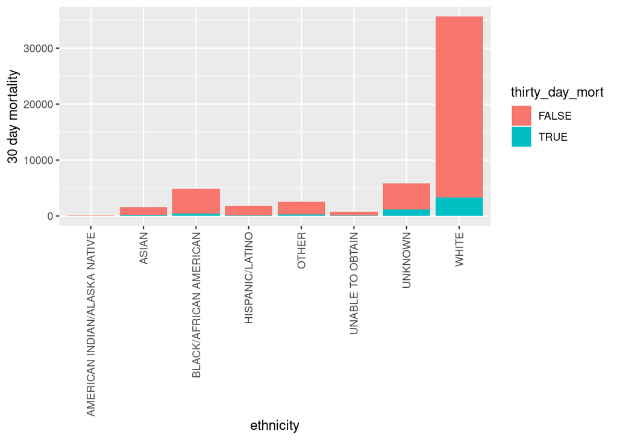

```r
mimic_icu_cohort %>%
  ggplot() +
  geom_bar(mapping = aes(x = ethnicity, fill = thirty_day_mort)) +
  theme(axis.text.x = element_text(angle = 90, vjust = 0.5, hjust = 1)) +
  labs(y = "30 day mortality")
```

*30 day mortality vs language*

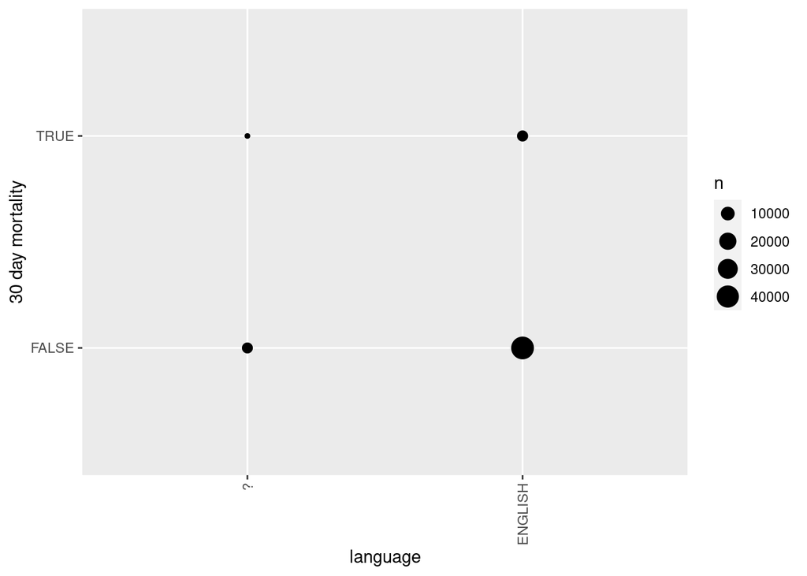

```r
mimic_icu_cohort %>%
  ggplot() +
  geom_count(mapping = aes(x = language, y = thirty_day_mort)) +
  theme(axis.text.x = element_text(angle = 90, vjust = 0.5, hjust = 1)) +
  labs(y = "30 day mortality")
```

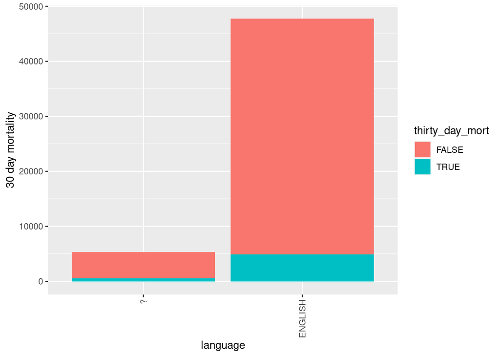

```r
mimic_icu_cohort %>%
  ggplot() +
  geom_bar(mapping = aes(x = language, fill = thirty_day_mort)) +
  theme(axis.text.x = element_text(angle = 90, vjust = 0.5, hjust = 1)) +
  labs(y = "30 day mortality")
```

*30 day mortality vs insurance*

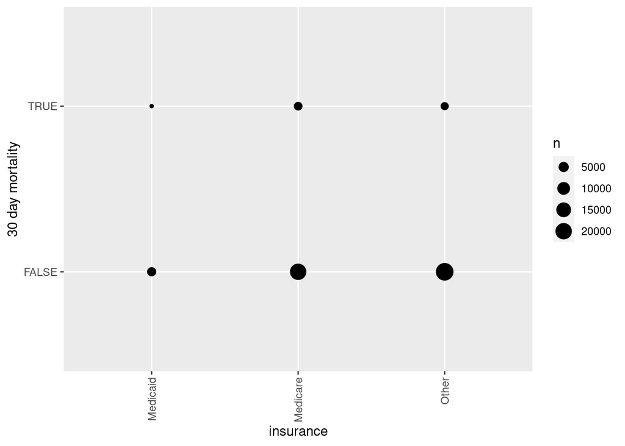

```r
mimic_icu_cohort %>%
  ggplot() +
  geom_count(mapping = aes(x = insurance, y = thirty_day_mort)) +
  theme(axis.text.x = element_text(angle = 90, vjust = 0.5, hjust = 1)) +
  labs(y = "30 day mortality")
```

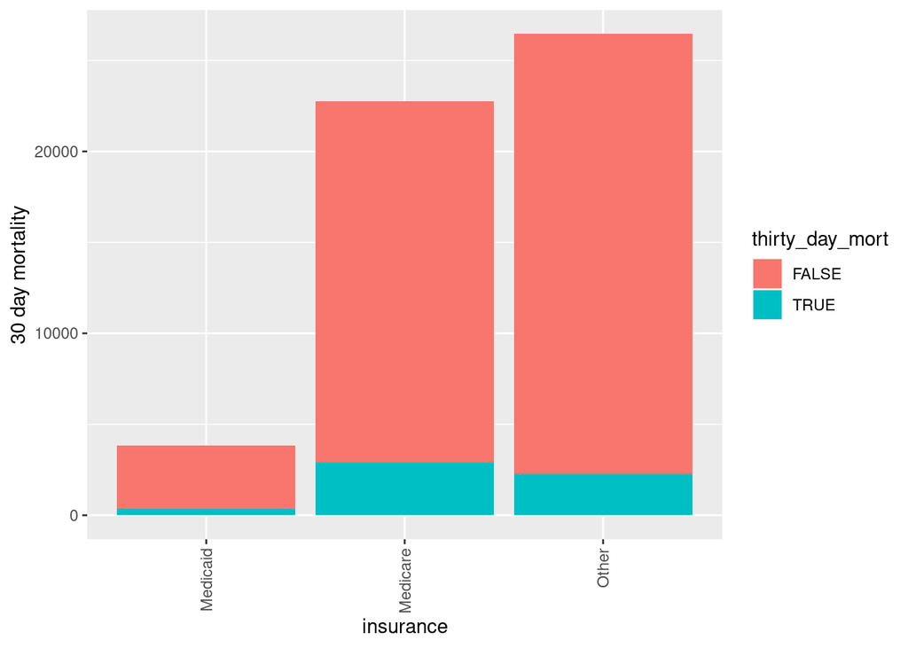

```r
mimic_icu_cohort %>%
  ggplot() +
  geom_bar(mapping = aes(x = insurance, fill = thirty_day_mort)) +
  theme(axis.text.x = element_text(angle = 90, vjust = 0.5, hjust = 1)) +
  labs(y = "30 day mortality")
```

*30 day mortality vs marital status*

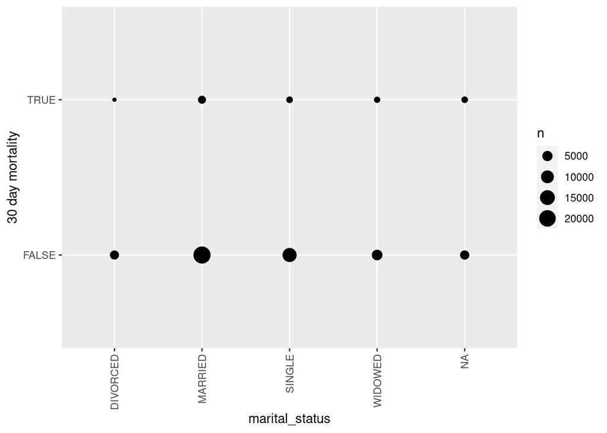

```r
mimic_icu_cohort %>%
  ggplot() +
  geom_count(mapping = aes(x = marital_status, y = thirty_day_mort)) +
  theme(axis.text.x = element_text(angle = 90, vjust = 0.5, hjust = 1)) +
  labs(y = "30 day mortality")
```

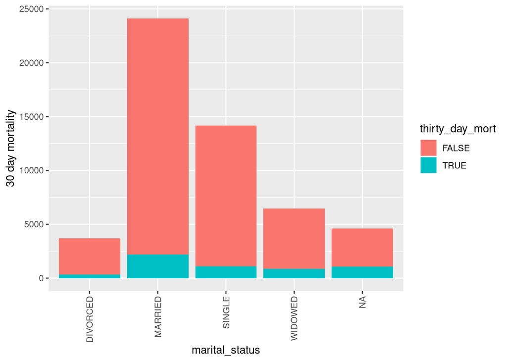

```r
mimic_icu_cohort %>%
  ggplot() +
  geom_bar(mapping = aes(x = marital_status, fill = thirty_day_mort)) +
  theme(axis.text.x = element_text(angle = 90, vjust = 0.5, hjust = 1)) +
  labs(y = "30 day mortality")
```

*30 day mortality vs gender*

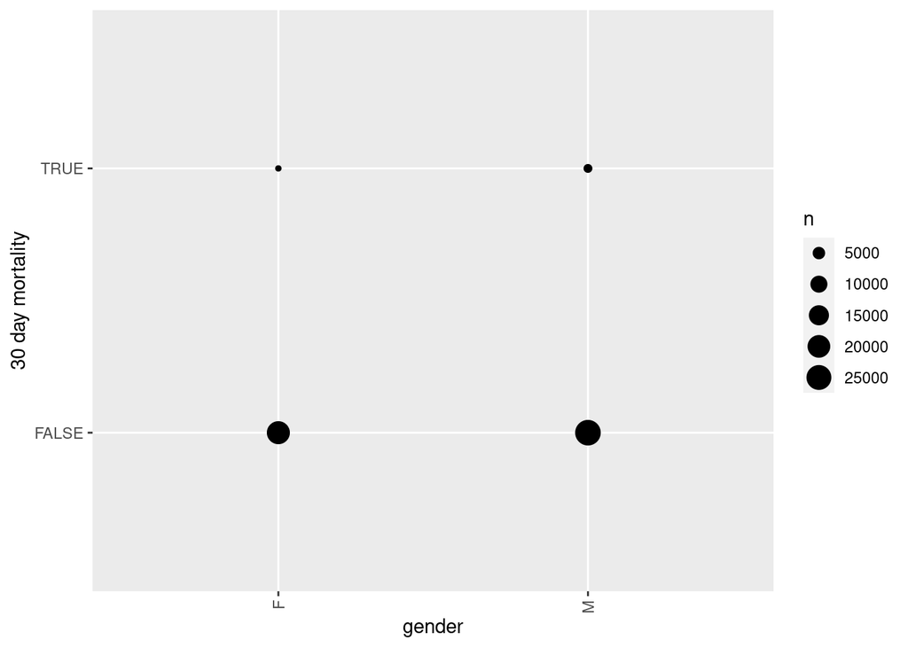

```r
mimic_icu_cohort %>%
  ggplot() +
  geom_count(mapping = aes(x = gender, y = thirty_day_mort)) +
  theme(axis.text.x = element_text(angle = 90, vjust = 0.5, hjust = 1)) +
  labs(y = "30 day mortality")
```